# R for Beginners

# Reports with R Markdown

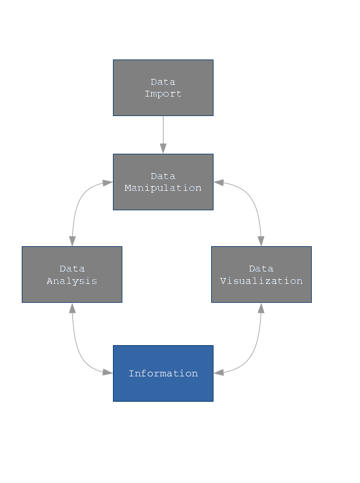

## Introduction

R Markdown provides an authoring framework for data science. R Markdown allows us to turn our analysis into high quality documents, reports, presentations and dashboards. We can use a single R Markdown file to both:

- save and execute code
- generate high quality reports that can be shared with an audience

R Markdown documents are fully reproducible and support multiple programming languages like: R, Python, and SQL. It support also dozens of static and dynamic output formats, including HTML, PDF, MS Word, Beamer, HTML5 slides, Tufte-style handouts, books, dashboards, shiny applications, scientific articles, websites, and more.

## Installation

You can install the R Markdown package from CRAN as follows:

```r
install.packages("rmarkdown")
```

## Markdown Basics

This is an R Markdown file, a plain text file that has the extension `.Rmd`:

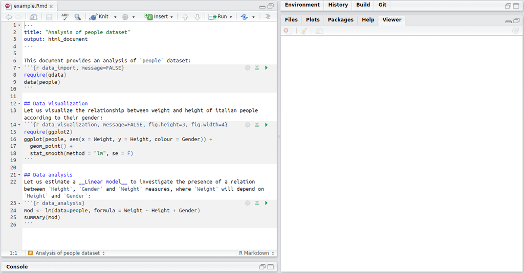

R Markdown File

Notice that the file contains three types of content:

- An (optional) YAML header surrounded by `---`
- R code chunks surrounded by `` ``` ``
- text mixed with simple text formatting

Markdown is a simple formatting language designed to make authoring content easy for everyone. Rather than writing complex markup code (e.g. HTML or LaTeX), Markdown enables the use of a syntax much more like plain-text email.

### Basic rules for text

This section provides quick references to the most commonly used R Markdown syntax.

#### Emphasis

If you want to write words in bold or italic, you have to follow the syntax:

`*italic*` `**bold**`  
*italic* **bold**

`_italic_` `__bold__`  
*italic* **bold**

You may also add colourful text:

`This is <span style="color:red"> coloured </span>`

#### Headers

To indicate titles of sections according to their hierarchy:

`# Header 1`

# Header

`## Header 2`

## Header

`### Header 3`

### Header

#### Lists

To create a list of items:

- Unordered List:

`* Item 1`  
`* Item 2`  
`+ Item 2a`  
`+ Item 2b`

- Item 1
- Item 2
  - Item 2a
  - Item 2b
- Ordered List:

`1. Item 1`  
`2. Item 2`  
`3. Item 3`  
`+ Item 3a`  
`+ Item 3b`

1. Item 1
2. Item 2
3. Item 3
   - Item 3a
   - Item 3b

#### Links

To add an http address or a link to a phrase:

`http://example.com`  
http://example.com

`[linked phrase](http://example.com)`  
[linked phrase](http://example.com)

#### Images

To add an images on the web or local files in the same directory:

`![alt text](http://example.com/logo.png)`

`![alt text](figures/img.png)`

`[alt text]` specifies the text to be inserted if the image is not displayed.

#### Inline Code

To include code out of the chunk, you have to enclose it in back-ticks:

We defined the ` add ` function to compute the sum of two numbers.

We defined the `add` function to compute the sum of two numbers.

#### Tables

If you want to create a table, you have to follow the the syntax:

`First Header | Second Header`  
`------------- | -------------`  
`Content Cell | Content Cell`  
`Content Cell | Content Cell`

| First Header | Second Header |
| --- | --- |
| Content Cell | Content Cell |
| Content Cell | Content Cell |

#### Manual Line Breaks

To create a line breaks, you have to end a line with two or more spaces:

Roses are red,  
Violets are blue.

## Rendering Output

To generate a report from the file, run the `render` command:

```r
require(rmarkdown)
render("example.Rmd")
```

Otherwise, use the “Knit” button in the RStudio IDE to render the file and preview the output with a single click or the keyboard shortcut *Ctrl + Shift + K*.

[figure not shown]

R Markdown Output

R Markdown generates a new file that contains selected text, code, and results from the .Rmd file. The new file can be a finished web page, PDF, MS Word document, slide show, notebook, handout, book, dashboard, package vignette or other format.

### Rendering tables with `knitr`

The `knitr` package provides a general-purpose tool for dynamic report generation in `R`.

Among its many functions, it can also help you to nicely render outputs. If you wish to show a table you may simply print the table as you commonly do in `R`:

```r
data(mtcars)
head(mtcars)
```

```
##                    mpg cyl disp  hp drat    wt  qsec vs am gear carb
## Mazda RX4         21.0   6  160 110 3.90 2.620 16.46  0  1    4    4
## Mazda RX4 Wag     21.0   6  160 110 3.90 2.875 17.02  0  1    4    4
## Datsun 710        22.8   4  108  93 3.85 2.320 18.61  1  1    4    1
## Hornet 4 Drive    21.4   6  258 110 3.08 3.215 19.44  1  0    3    1
## Hornet Sportabout 18.7   8  360 175 3.15 3.440 17.02  0  0    3    2
## Valiant           18.1   6  225 105 2.76 3.460 20.22  1  0    3    1
```

However, you may want your table to look nicer. The `knitr` package allows you to easily do so with the function `kable`:

```r
knitr::kable(head(mtcars))
```

|  | mpg | cyl | disp | hp | drat | wt | qsec | vs | am | gear | carb |
| --- | --- | --- | --- | --- | --- | --- | --- | --- | --- | --- | --- |
| Mazda RX4 | 21.0 | 6 | 160 | 110 | 3.90 | 2.620 | 16.46 | 0 | 1 | 4 | 4 |
| Mazda RX4 Wag | 21.0 | 6 | 160 | 110 | 3.90 | 2.875 | 17.02 | 0 | 1 | 4 | 4 |
| Datsun 710 | 22.8 | 4 | 108 | 93 | 3.85 | 2.320 | 18.61 | 1 | 1 | 4 | 1 |
| Hornet 4 Drive | 21.4 | 6 | 258 | 110 | 3.08 | 3.215 | 19.44 | 1 | 0 | 3 | 1 |
| Hornet Sportabout | 18.7 | 8 | 360 | 175 | 3.15 | 3.440 | 17.02 | 0 | 0 | 3 | 2 |
| Valiant | 18.1 | 6 | 225 | 105 | 2.76 | 3.460 | 20.22 | 1 | 0 | 3 | 1 |

### Hide code and messages

If you are taking notes or you are writing a manual for other R users, you may want to show the code along with the output and some other times you may want to show just the code. Some other times, for examples if you are just creating a report, you may want to hide the code and only show the output. These sorts of actions can be changed for all code chunks by adding some options to each code chunk.